# Lab: Week 10 – Solutions

## Question 15

*(5 points)*

*Notes 10B (8-9)*

Plot the autocorrelation function (acf) for the `air.passengers` time series. From its appearance, do you think that the random portion of the `air.passengers` time series is well-modeled? (The appearance of the random component in the decomposition plot might offer a clue here.)

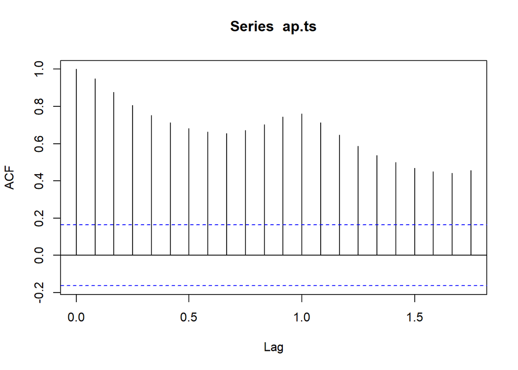

```
The random component in the decomposition plot indicates that the estimate
of the seasonal component is not optimal; the fact that the acf has a peak
at lag 1 is consistent with this.
```

```r
plot(acf(ap.ts))
```

## Question 16

*(5 points)*

*Notes 10C (4-8)*

As stated in the notes, we don’t have to cast an input time series to class `ts` prior to creating a periodogram, but it doesn’t necessarily hurt to do so. Plot the periodogram of your `air.passengers` time series. Set `log="no"`. What do you see? Google “harmonics periodogram” and explain what you see. (Note that a linear trend was removed prior to spectral decomposition!)

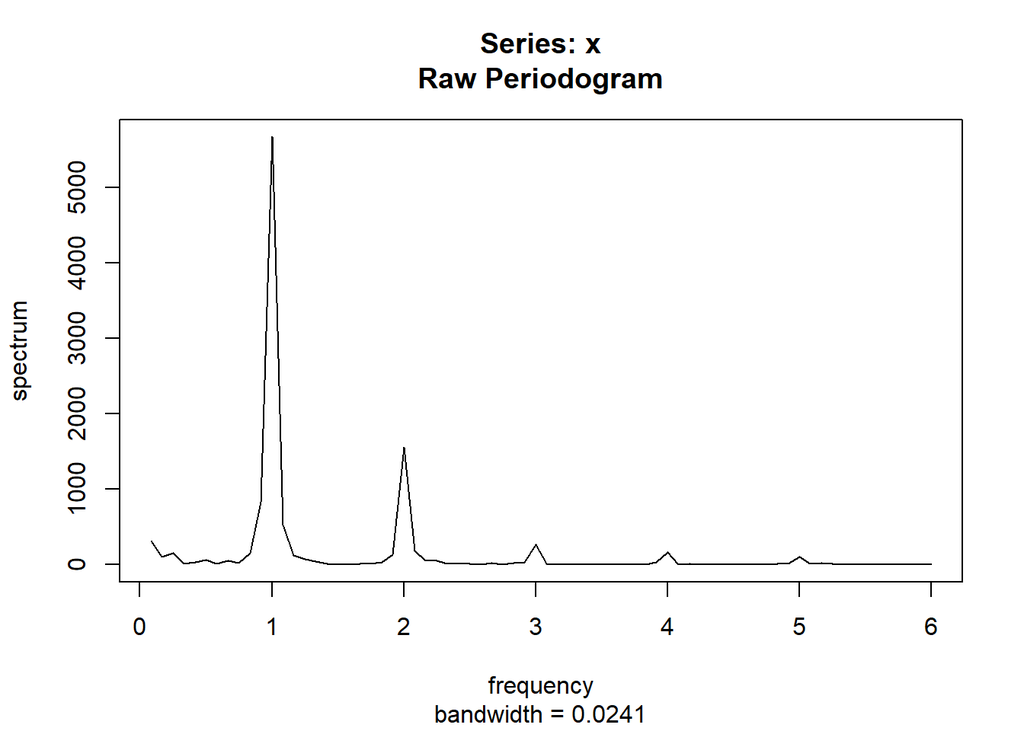

```
There is a strong seasonal signal. Because this signal is not a
pure sinusoid, there is power at multiples of the so-called
"fundamental frequency". These signals are dubbed harmonics.

TL;DR: the seasonal signal is not a sinusoid, hence harmonics.
```

```r
spectrum(ap.ts,log="no")
```

## Question 17

*(5 points)*

*Notes 10C (4-8)*

Plot the periodogram for the seasonal component of your decomposition of the `air.passengers` time series. You should observe something similar to what you observed in Q16.

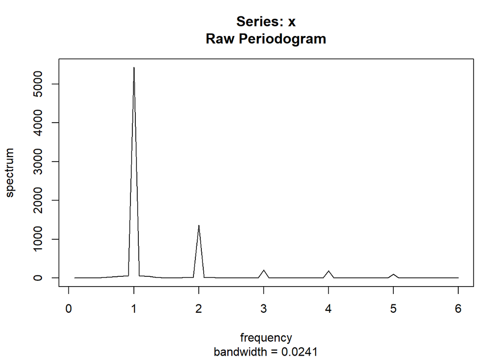

```r
spectrum(ap.ts.dec$seasonal,log="no")
```

## Question 18

*(5 points)*

*Notes 10C (8)*

Now plot the periodogram for the random component of your decomposition of the `air.passengers` time series. When you get rid of the `NA`s in the `random` vector, the time series element is lost. So here, after you get rid of the `NA`s, cast `random` back to a `ts`-class object, with the `start` being July 1949. Then pass `random` on… What do you observe? Compare the amplitudes of the peaks to the amplitudes you see above in the plot for Q17. Is there any visual evidence for a non-seasonal periodic component to the data?

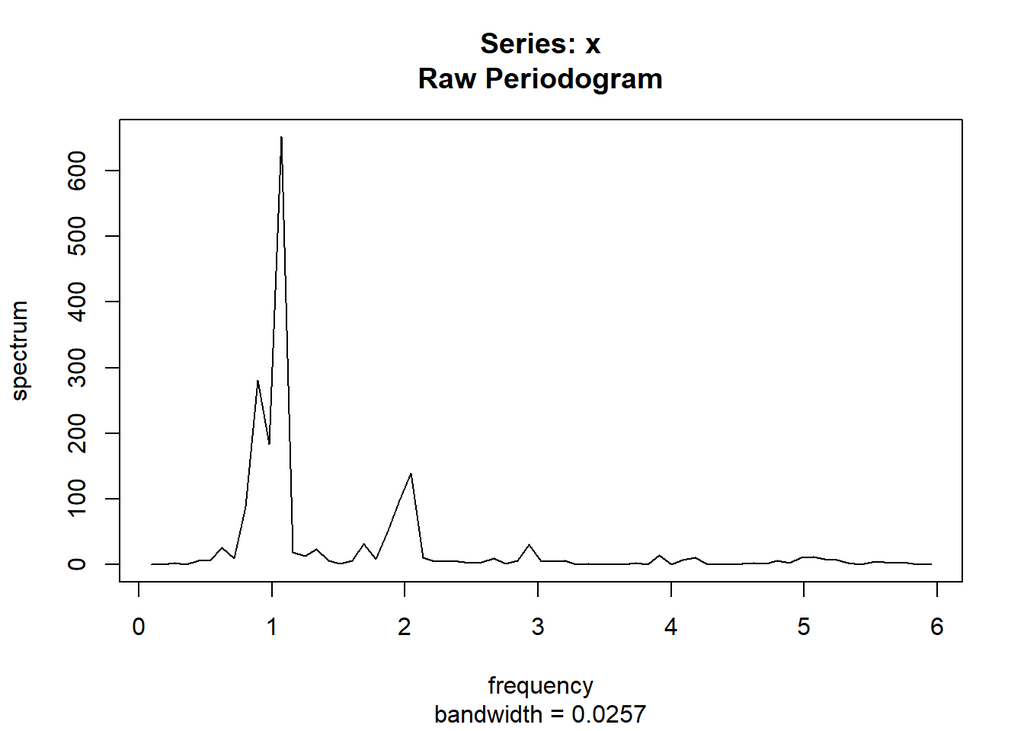

```
We observe residual seasonal effects with roughly 1/10th the
power of what we observe in Q17. These residual effects are not
purely sinusoidal, hence the continued presence of harmonics.
```

```r
random = ap.ts.dec$random
random = ts(random[is.na(random)==FALSE],start=c(1949,7),frequency=12)
spectrum(random,log="no")
```